# Homework3

Yilin Yang

2022-10-04

##### In this section, I used Naive Bayes to identify the relationship between influence scores and different factors of being a instagram influencer. Naive Bayes is a classification method based on Bayes’ Theorem and the assumption of predictor independence. It performs well in the case of categorical input variables compared to the numerical variables.

```r
#import required packages
library(e1071)
library(caTools)
library(caret)
```

```r
library(plotly)
library(dplyr)
library(ggplot2)
library(psych)
```

#### Import data

```r
#Load and split the dataset
data = read.csv("/Users/yangyilin/Desktop/anly-501-project-YilinYang2000-1//data/00-raw-data/instagram_infl.csv")
```

```r
head(data)
```

```
##   X rank  channel_info influence_score posts.k. followers.m.
## 1 1    1     cristiano              92     3.30        475.8
## 2 2    2   kyliejenner              91     6.90        366.2
## 3 3    3      leomessi              90     0.89        357.3
## 4 4    4   selenagomez              93     1.80        342.7
## 5 5    5       therock              91     6.80        334.1
## 6 6    6 kimkardashian              91     5.60        329.2
##   X60_day_eng_rate... new_post_avg_like.m. total_likes.b.       country
## 1                1.39                  6.5           29.0         Spain
## 2                1.62                  5.9           57.4 United States
## 3                1.24                  4.4            6.0     Undefined
## 4                0.97                  3.3           11.5 United States
## 5                0.20                665.3           12.5 United States
## 6                0.88                  2.9           19.9 United States
##   avg_likes
## 1   8700000
## 2   8300000
## 3   6800000
## 4   6200000
## 5   1900000
## 6   3500000
```

The dataset contains 11 columns.

influence score: It is calculated based on their popularity.

posts: total posts they have

followers: total followers they have

avg_likes: average likes of their total posts

60_days_eng_rate: 60 days of engagement rate

new_post_avg_like: a calculation of the average likes they gained from new posts.

total_likes: total likes of their posts in instagram.

country: users’ origin. What countries they from?

#### Identify frequencies

At this time, I want to calculate the distribution of influence scores.

```r
xtabs(~data$influence_score, data = data)
```

```
## data$influence_score
## 22 41 42 47 57 58 63 68 70 71 72 73 74 75 76 77 78 79 80 81 82 83 84 85 86 87
##  1  1  2  1  1  1  1  1  1  1  1  2  3  4  6  4  6  6 12  9 12 20 17 30 19  9
## 88 89 90 91 92 93
##  7  4  7  6  4  1
```

```r
data <- data %>% mutate(new_bin = cut(influence_score, breaks=c(0,77,84,100)))#cut influence scores into different bins
data$new_bin <- as.character(data$new_bin)

data$new_bin[data$new_bin=="(0,77]"]<-"low"
data$new_bin[data$new_bin=="(77,84]"]<-"medium"
data$new_bin[data$new_bin=="(84,100]"]<-"high"
# Catergorized scores between 0-60 as low scores, 60-85 as medium scores,85-100 as high scores
data$new_bin <- as.factor(data$new_bin) # Factorize the column new_bin for futher classification
```

#### Split dataset into train and test

```r
split <- sample.split(data, SplitRatio = 0.8)
train <- subset(data, split == "TRUE")
test <- subset(data, split == "FALSE")
train <- subset(train,select = -c(X,channel_info,country,rank,influence_score)) #Drop columns which are not required
test <- subset(test,select = -c(X,channel_info,country,rank,influence_score))
```

```r
head(train)
```

```
##   posts.k. followers.m. X60_day_eng_rate... new_post_avg_like.m. total_likes.b.
## 1     3.30        475.8                1.39                  6.5           29.0
## 2     6.90        366.2                1.62                  5.9           57.4
## 3     0.89        357.3                1.24                  4.4            6.0
## 5     6.80        334.1                0.20                665.3           12.5
## 6     5.60        329.2                0.88                  2.9           19.9
## 7     5.00        327.7                1.20                  3.9           18.4
##   avg_likes new_bin
## 1   8700000    high
## 2   8300000    high
## 3   6800000    high
## 5   1900000    high
## 6   3500000    high
## 7   3700000    high
```

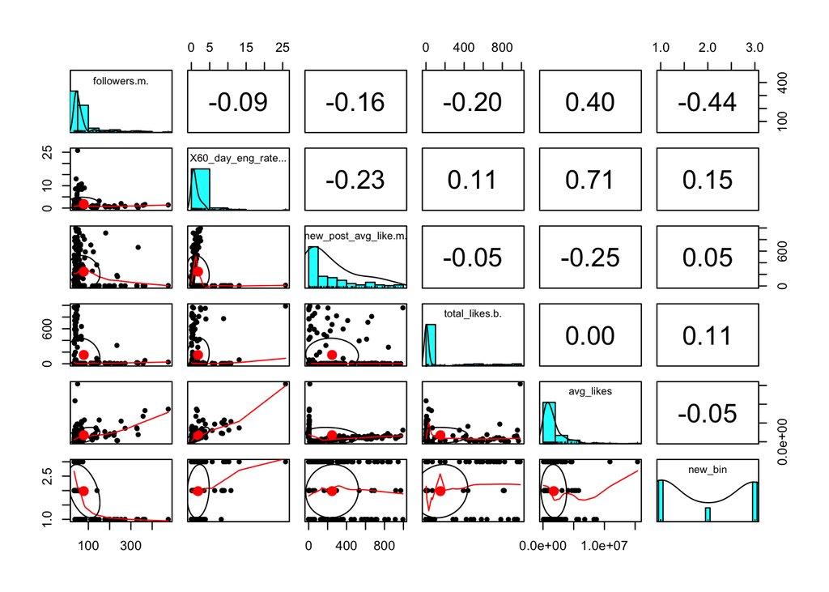

```r
pairs.panels(train[-1])
```

#### Naive Bayes Classification

```r
model <- naiveBayes(new_bin ~ ., data = train, usekernel = T)
```

```r
y_pred <- predict(model, newdata = test)
conf_mat <- table(test$new_bin,y_pred)
confusionMatrix(conf_mat)
```

```
## Confusion Matrix and Statistics
##
##         y_pred
##          high low medium
##   high     12   0      9
##   low       2   1      6
##   medium    2   2     15
##
## Overall Statistics
##
##                Accuracy : 0.5714
##                  95% CI : (0.4221, 0.7118)
##     No Information Rate : 0.6122
##     P-Value [Acc > NIR] : 0.76962
##
##                   Kappa : 0.299
##
##  Mcnemar's Test P-Value : 0.03749
##
## Statistics by Class:
##
##                      Class: high Class: low Class: medium
## Sensitivity               0.7500    0.33333        0.5000
## Specificity               0.7273    0.82609        0.7895
## Pos Pred Value            0.5714    0.11111        0.7895
## Neg Pred Value            0.8571    0.95000        0.5000
## Prevalence                0.3265    0.06122        0.6122
## Detection Rate            0.2449    0.02041        0.3061
## Detection Prevalence      0.4286    0.18367        0.3878
## Balanced Accuracy         0.7386    0.57971        0.6447
```

#### Build a heatmap for visualization

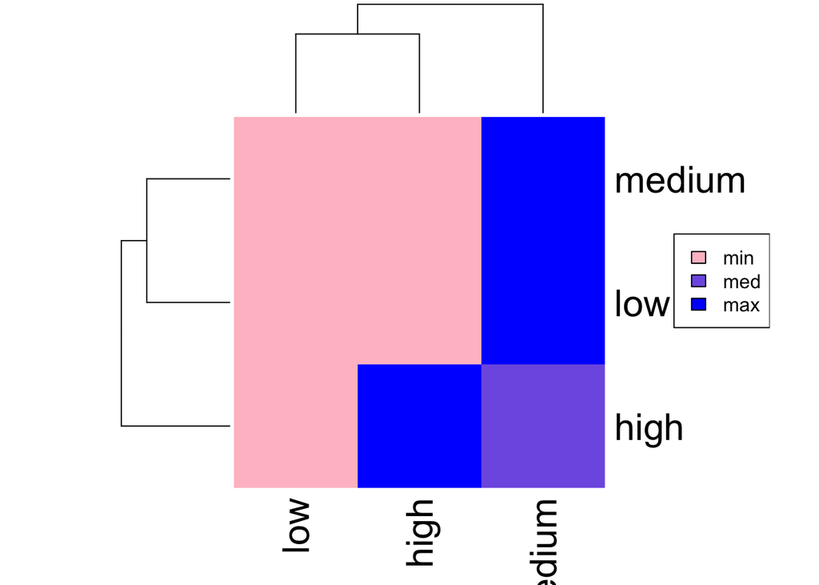

```r
my_colors <- colorRampPalette(c("pink", "blue"))
heatmap(conf_mat,col = my_colors(3))
legend(x="right",legend = c("min", "med", "max"),fill = my_colors(3))
```

##### Conclusion

As we can see in the confusion matrix, The accuracy is only low for prediction. At this time, Naive Bayes is not a good model for this dataset. In naive Bayes algorithm, we calculate the conditional probability of the events given class label. However in testing data, if some new event comes up then the conditional probability will be zero for the entire term. As a result, it is may be not useful for this dataset because other variables don’t give a great prediction for influencers’ scores. Influencer score may be not a independent variable.

##### Train another model in the same plots

At this time, I want to total likes amount to train influence model too determine whether there are other interrupted variables lower the accuracy

```r
model <- naiveBayes(new_bin ~ total_likes.b., data = train, usekernel = T)
y_pred <- predict(model, newdata = test)
conf_mat <- table(test$new_bin,y_pred)
confusionMatrix(conf_mat)
```

```
## Confusion Matrix and Statistics
##
##         y_pred
##          high low medium
##   high     16   0      5
##   low       9   0      0
##   medium   15   0      4
##
## Overall Statistics
##
##                Accuracy : 0.4082
##                  95% CI : (0.27, 0.5579)
##     No Information Rate : 0.8163
##     P-Value [Acc > NIR] : 1
##
##                   Kappa : -0.0223
##
##  Mcnemar's Test P-Value : NA
##
## Statistics by Class:
##
##                      Class: high Class: low Class: medium
## Sensitivity               0.4000         NA       0.44444
## Specificity               0.4444     0.8163       0.62500
## Pos Pred Value            0.7619         NA       0.21053
## Neg Pred Value            0.1429         NA       0.83333
## Prevalence                0.8163     0.0000       0.18367
## Detection Rate            0.3265     0.0000       0.08163
## Detection Prevalence      0.4286     0.1837       0.38776
## Balanced Accuracy         0.4222         NA       0.53472
```

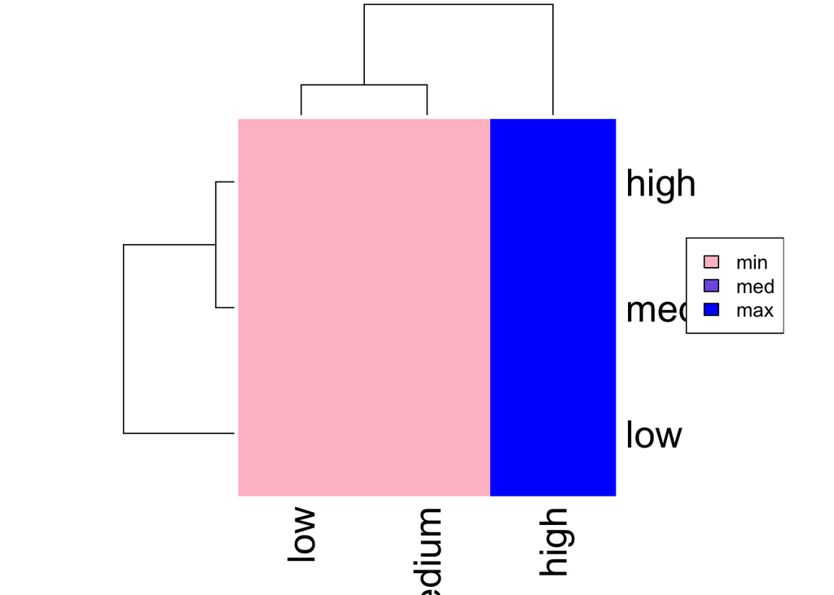

```r
my_colors <- colorRampPalette(c("pink", "blue"))
heatmap(conf_mat,col = my_colors(3))
legend(x="right",legend = c("min", "med", "max"),fill = my_colors(3))
```

##### Conclusion

Because the accuracy is still low at this time, we can conclude that Naive Bayes is not suitable for this model.